# 2019_09_15_linear_algebra

## Cross product in 3D

In the vector space $\mathbb{R}^3$, there is a vector operation that can compute an orthogonal vector from two other vectors.

$$ \mathbf{u}\times\mathbf{v} = \left[\begin{array}{c} u_2v_3-u_3v_2 \\ u_3v_1-u_1v_3 \\ u_1v_2-u_2v_1 \end{array}\right]$$

```python
def plot_3d_vectors(x, *E, **F):
  names = E[0::2]
  vectors = E[1::2]
  V = np.array(vectors)
  m = np.max(np.abs(V)) * 1.5
  ax.set_xlim(-m, m)
  ax.set_ylim(-m, m)
  ax.set_zlim(-m, m)
  ax.scatter(V[:, 0], V[:, 1], V[:, 2])
  for label, v in zip(names, vectors):
    ax.plot([0, v[0]], [0, v[1]], [0, v[2]])
    ax.text(v[0], v[1], v[2], label)
```

```python
def cross_product(u, v):
    w1 = u[1]*v[2] - u[2]*v[1]
    w2 = u[2]*v[0] - u[0]*v[2]
    w3 = u[0]*v[1] - u[1]*v[0]
    return np.array([w1, w2, w3])
```

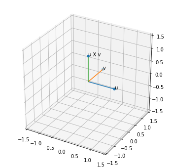

```python
u = np.array([1., 0, 0.])
v = np.array([0, 1, 0.])
w = cross_product(u, v)

fig = pl.figure(figsize=(6, 6))
ax = fig.add_subplot(1,1,1, projection='3d')
plot_3d_vectors(ax, 'u', u, 'v', v, 'u X v', w, fontsize=20)
```

# Objects in vector spaces

## Point = Vector

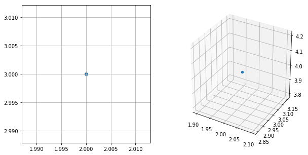

```python
# A point is a vector
fig = pl.figure(figsize=(10,5))
ax = fig.add_subplot(1,2,1)
ax.scatter
ax.scatter([2.], [3.]);
ax.grid(True)

ax = fig.add_subplot(1,2,2, projection='3d')
ax.scatter([2.], [3.], [4.]);
```

## Line

A line is a set of points with the property that they are all co-linear.

- an infinite line: $ L = \{a \mathbf{v} + \mathbf{u}: -\infty < a < \infty\}$
- a finite line segment: $L = \{a \mathbf{v} + \mathbf{u} : 0 \leq a \leq 1\}$

```python
# Generating a set of colinear points in 2D
A = np.linspace(-1, 1, 20)
A
```

```
array([-1.        , -0.89473684, -0.78947368, -0.68421053, -0.57894737,
       -0.47368421, -0.36842105, -0.26315789, -0.15789474, -0.05263158,
        0.05263158,  0.15789474,  0.26315789,  0.36842105,  0.47368421,
        0.57894737,  0.68421053,  0.78947368,  0.89473684,  1.        ])
```

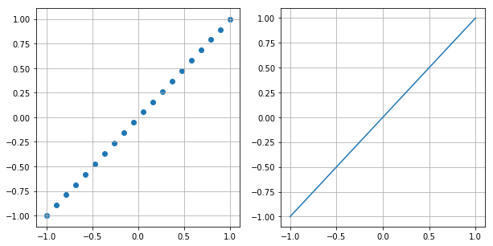

```python
v1 = np.array([1, 1.])
line = np.array([a * v1 for a in A])
fig = pl.figure(figsize=(10,5))
pl.subplot(1,2,1)
pl.grid(True)
pl.scatter(line[:,0], line[:,1]);

# Plot as a line
pl.subplot(1,2,2)
pl.plot(line[:,0], line[:,1]);
pl.grid(True)
```

```
scalars:
 [-1.         -0.89473684 -0.78947368 -0.68421053 -0.57894737 -0.47368421
 -0.36842105 -0.26315789 -0.15789474 -0.05263158  0.05263158  0.15789474
  0.26315789  0.36842105  0.47368421  0.57894737  0.68421053  0.78947368
  0.89473684  1.        ]
points:
 [[ 9.          8.          2.        ]
 [ 9.10526316  8.21052632  2.31578947]
 [ 9.21052632  8.42105263  2.63157895]
 [ 9.31578947  8.63157895  2.94736842]
 [ 9.42105263  8.84210526  3.26315789]
 [ 9.52631579  9.05263158  3.57894737]
 [ 9.63157895  9.26315789  3.89473684]
 [ 9.73684211  9.47368421  4.21052632]
 [ 9.84210526  9.68421053  4.52631579]
 [ 9.94736842  9.89473684  4.84210526]
 [10.05263158 10.10526316  5.15789474]
 [10.15789474 10.31578947  5.47368421]
 [10.26315789 10.52631579  5.78947368]
 [10.36842105 10.73684211  6.10526316]
 [10.47368421 10.94736842  6.42105263]
 [10.57894737 11.15789474  6.73684211]
 [10.68421053 11.36842105  7.05263158]
 [10.78947368 11.57894737  7.36842105]
 [10.89473684 11.78947368  7.68421053]
 [11.         12.          8.        ]]
```

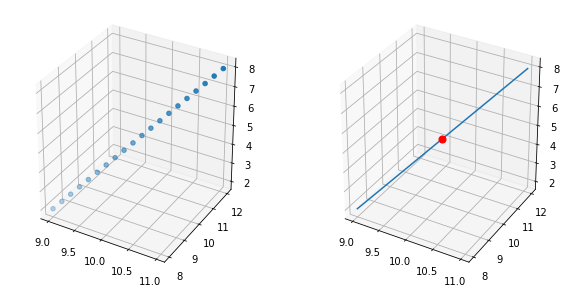

```python
# Line in 3D
print("scalars:\n", A)
u = np.array([10., 10., 5.])
v = np.array([1.,2.,3.])
line = np.array([a * v for a in A]) + u
print("points:\n", line)

fig = pl.figure(figsize=(10, 5))
ax = fig.add_subplot(1,2,1, projection='3d')
ax.scatter(line[:,0], line[:,1], line[:,2])

ax = fig.add_subplot(1,2,2, projection='3d')
ax.plot(line[:,0], line[:,1], line[:,2]);
ax.scatter([u[0]], [u[1]], [u[2]], c='red', s=50);
```

# Planes

Planes are sets of points that are linear combinations of two vectors. The two vectors must *not* be co-linear.

$$ P = \{a\mathbf{u} + b\mathbf{v} + \mathbf{w} : a, b\in \mathbb{R}\}$$

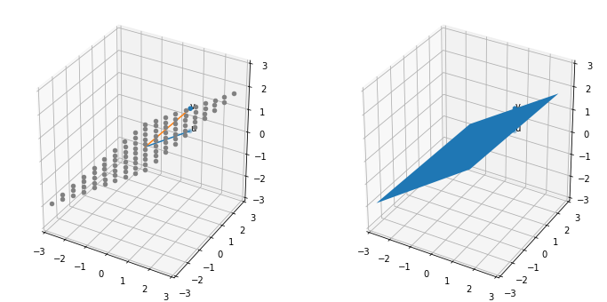

```python
from mpl_toolkits.mplot3d.art3d import Poly3DCollection

u = np.array([1, 2, 0.])
v = np.array([1, 2, 1])

A = np.linspace(-1, 1, 10)
B = np.linspace(-1, 1, 10)
plane = np.array([a*u + b*v for a in A for b in B])

fig = pl.figure(figsize=(12, 6))
ax = fig.add_subplot(1, 2, 1, projection='3d')
plot_3d_vectors(ax, 'u', u, 'v', v)
for x in plane:
    ax.scatter([x[0]], [x[1]], [x[2]], color='grey')

ax = fig.add_subplot(1, 2, 2, projection='3d')
corner1 = -u -v
corner2 = -u + v
corner3 = u + v
corner4 = u - v
p = [corner1, corner2, corner3, corner4]
ax.add_collection3d(Poly3DCollection([p]))
plot_3d_vectors(ax, 'u', u, 'v', v)
```

## Normal vector of a plane

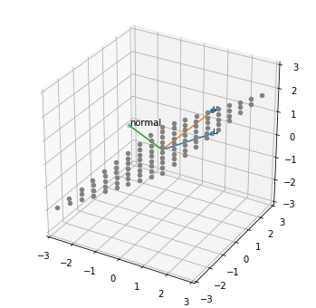

```python
fig = pl.figure(figsize=(6, 6))
ax = fig.add_subplot(1, 1, 1, projection='3d')
plot_3d_vectors(ax, 'u', u, 'v', v, 'normal', cross_product(v, u))
for x in plane:
    ax.scatter([x[0]], [x[1]], [x[2]], color='grey')
```

# Projections and distances

## Distances

What is the distance between two vectors:

- $d(\mathbf{u}, \mathbf{v}) = |\mathbf{u}-\mathbf{v}|$

What is the distance between a vector $\mathbf{u}$ and a line $L$?

- We need to compute the projection of $\mathbf{u}$ on to the line $L$: $\mathrm{proj}(\mathbf{u}, L)$
- Then compute the distance $d(\mathbf{u}, \mathrm{proj}(\mathbf{u}, L))$

## Distances

What is the distance between a vector $\mathbf{x}$ and a line $L$?

- We need to compute the projection of $\mathbf{x}$ on to the line $L$: $\mathrm{proj}(\mathbf{x}, L)$
- Then compute the distance $d(\mathbf{x}, \mathrm{proj}(\mathbf{x}, L))$

## Distances: vector to plane

What is the distance between a vector $\mathbf{x}$ and a plane $P$?

- We need to compute the projection of $\mathbf{x}$ onto the plane P: $\mathrm{proj}(\mathbf{x}, P)$
- Then compute the distance $d(\mathbf{x}, \mathrm{proj}(\mathbf{x}, P))$

## Projection onto a line

- Let a line be defined by its direction vector $\mathbf{u}$, where $|\mathbf{u}| = 1$.

How do we project $\mathbf{x}$ to the line $L(\mathbf{u})$? Let $\mathbf{y} = \mathrm{proj}(\mathbf{x}, L(\mathbf{u}))$

Observe:

- $\mathbf{y}$ is colinear to $\mathbf{u}$.
- $$|\mathbf{y}| = |\mathbf{x}|\cos(\theta) = |\mathbf{x}| \frac{\left<\mathbf{x},\mathbf{u}\right>} {|\mathbf{x}| |\mathbf{u}|} = \left<\mathbf{x}, \mathbf{u}\right>$$

Thus,

$$ \mathbf{y} = \left<\mathbf{x}, \mathbf{u}\right> \mathbf{u} $$

```python
u = np.array([1.5, 1.4, 2.0])
u = u / np.linalg.norm(u)

x = np.array([1, 2.5, 4.])
proj = np.dot(x, u) * u
print("proj(x, L) = %s" % proj)
print("dist(x, L) = %.2f" % np.linalg.norm(x - proj))
```

```
proj(x, L) = [2.37515225 2.21680877 3.16686967]
dist(x, L) = 1.63
```

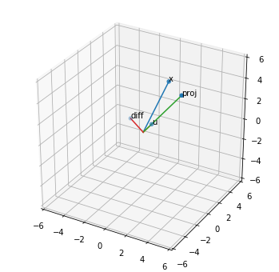

```python
fig = pl.figure(figsize=(6,6))
ax = fig.add_subplot(1, 1, 1, projection='3d')
plot_3d_vectors(ax, 'x', x, 'u', u, 'proj', proj, 'diff', x-proj)
```

## Projection onto a plane

Consider a vector $\mathbf{x}$.

Let a plane be defined by its two directional vectors $\mathbf{u}$ and $\mathbf{v}$. So, we write the plane as $P(\mathbf{u}, \mathbf{v})$.

- First we compute the normal vector $\mathbf{n} = \mathbf{u}\times\mathbf{v}$.
- We project the vector onto $L(\mathbf{n})$, and obtain $\mathbf{y_1} = \mathrm{proj}(\mathbf{x}, L(\mathbf{n}))$.
- Now we can compute the projection onto the plane as: $$\mathrm{proj}(\mathbf{x}, P) = \mathbf{x} - \mathrm{proj}(x, L(\mathbf{n}))$$
- The distance is given: $$d(\mathbf{x}, P) = |\mathrm{proj}(x, L(\mathbf{n}))|$$

```python
x = np.array([2.5, 1.4, 3])
u = np.array([1, 0, 0.])
v = np.array([0, 1, 0.])

n = cross_product(u, v)
n = n / np.linalg.norm(n)

proj_n = np.dot(x, n) * n
proj = x - proj_n
proj
```

```
array([2.5, 1.4, 0. ])
```

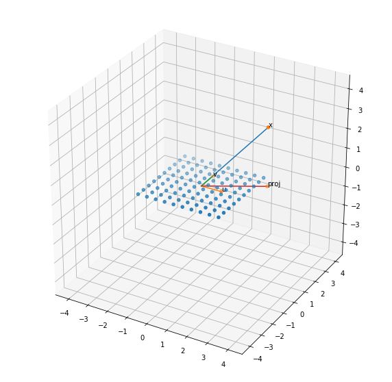

```python
fig = pl.figure(figsize=(10,10))
ax = fig.add_subplot(1,1,1, projection='3d')

A = np.linspace(-2, 2, 10)
B = np.linspace(-2, 2, 10)
plane = np.array([a*u + b*v for a in A for b in B])
ax.scatter(plane[:,0], plane[:,1], plane[:,2])
plot_3d_vectors(ax, 'x', x, 'u', u, 'v', v, 'proj', proj)
```